# Homework #2

**See Canvas for HW #2 assignment due date**. Complete all of the following problems. Ideally, the theoretical problems should be answered in a Markdown cell directly underneath the question. If you don't know LaTex/Markdown, you may submit separate handwritten solutions to the theoretical problems, but please see the [class scanning policy](https://docs.google.com/document/d/17y5ksolrn2rEuXYBv_3HeZhkPbYwt48UojNT1OvcB_w/edit?usp=sharing). Please do not turn in messy work. Computational problems should be completed in this notebook (using the R kernel). Computational questions may require code, plots, analysis, interpretation, etc. Working in small groups is allowed, but it is important that you make an effort to master the material and hand in your own work.

## A.1 Some probability calculations

**A.1(a) [8 points] The CU Boulder triathlon team has 12 women and 9 men. The team is going to a race and can only enter 5 participants. What is the probability of randomly selecting a race squad of 5 participants with exactly 3 women?**

$(\frac{12}{21})(\frac{11}{20})(\frac{10}{19})(\frac{9}{18})(\frac{8}{17})\binom53 \approx 0.38$

**A.1(b) [8 points] What is the probability that that at least two people in a room of 45 have the same birthday? Assume that all possible birthdays are equally likely, and ignore leap year. (HINT: You might consider using the theorem $P(A^C) = 1−P(A)$.)**

From the hint, lets look at 45 people who will have different birthdays.

$P(A) = P(45$ diff. birthdays$) = (\frac{365}{365})(\frac{364}{365})(\frac{363}{365}) \ldots (\frac{321}{365}) = \frac{365\cdot364\cdot363\cdots321}{365^{45}} \approx 0.059$

Now, as mentioned from the hint, if the probability of 45 people having different birthdays is $0.059$, then the compliment would mean the probability of 2 people having the same birthday.

$P(A^c) = 1 - P(A) = 1 - 0.059 = 0.941$

**A.1(c) [10 points] Three dice are thrown. What is the probability that a sum of 12 appears on the faces? What is the probability that a sum of 13 appears?**

To find the probability that a sum of 12 appears on the faces of 3 dices, we must first look at the possible sums from 3 dices.

$D_{12} = \{(6,5,1),(4,3,5),(5,5,2),(6,4,2),(6,3,3),(4,4,4)\}$

Using permutations algorithm, $P(n,r) = \frac{n!}{(n-r)!}$ we find that for elements in the set that have 3 different values the combination is 6, for elements that have 2 different values the combination is 3, and for 1 distinct value the combinatin is 1.

$(6,5,1) = P(3,2) = \frac{3!}{(3-2)!} = 6$, $\newline(4,3,5) = P(3,2) = \frac{3!}{(3-2)!} = 6$ $\newline(5,5,2) = P(3,1) = \frac{3!}{(3-1)!} = 3$ $\newline(6,4,2) = P(3,2) = \frac{3!}{(3-2)!} = 6$ $\newline(6,3,3) = P(3,1) = \frac{3!}{(3-1)!} = 3$ $\newline(4,4,4) = P(3,0) = \frac{3!}{(3-0)!} = 1$

Therefore, their are 25 different combinations. $\newline P(D_{12}) = \frac{25}{6^3} \approx 0.1157$

We do similar work for the probability that a sum of 13 appears on the faces of 3 dices.

$P(D_{13}) = \{(5,4,4),(4,6,3),(6,6,1), (5,5,3),(4,3,6) \}$

$P(D_{13}) = \frac{21}{216} = \approx 0.097$

## A.2 Probability and causality!

What does it mean for one event C to cause another event E—for example, smoking (C) to cause cancer (E)? There is a long history in philosophy, statistics, and the sciences of trying to clearly analyze the concept of a cause. One tradition says that causes raise the probability of their effects; we may write this symbolically is $$ \begin{equation} P(E | C)>P(E). \end{equation} \qquad \qquad (1) $$

**A.2(a) [6 points] Does equation (1) imply that $P(C | E) > P(C)$? If so, prove it. If not, give a counter example.**

No. From looking at the example given above, smoking (C) to cause cancer (E), the opposite is not true. Cancer(E) to cause smoke (C) is no true. Therefore $P(C|E) > P(C)$ in not true in this case.

Another way to formulate a probabilistic theory of causation is to say that $$P (E | C) > P(E | C^C). \qquad \qquad (2)$$

**A.2(b) [6 points] Show that equation (1) from A.2(a) implies equation (2).**

We want to show that $P(E|C) > P(E) \Rightarrow P(E|C) > P(E|C^c$) $\newline$First, lets note that $P(E) = P(E|C)P(C) + P(E|C^c)P(C^c)$ and $P(C^c) = 1 - P(C)$

$P(E|C) > P(E)$ $\newline \Rightarrow P(E|C) > P(E|C)P(C) + P(E|C^c)P(C^c)$ $\newline \Rightarrow P(E|C) - P(E|C)P(C) > P(E|C^c)(1-P(C))$ $\newline \Rightarrow P(E|C)(1 - P(C)) > P(E|C^c)(1-P(C))$

Divide $1-P(C)$ from both sides and we obtain:

$P(E|C) > P(E|C^c) $

**A.2(c): [4 points] Let C be the drop in the level of mercury in a barometer and let E be a storm. Briefly describe why this leads to a problem with using equation (1) (or equation (2)) as a theory of causation.**

Equation (1) or (2) leads to a problem as a theory of causation because in determining and measuring a possible storm there many variables and factors to take account of. A drop in the level of mercury in a barometer is not enough to cause a storm there are other factors to consider. Otherwise, our predictions on the weather would be nearly perfect if all that mattered was the level of mercury. That is the problem with equation (1) or (2), it lacks calculations in systems that are more dynamic and complicated.

Let A, C, and E be events. If $P(E | A \cap C) = P(E |C )$, then C is said to screen A off from E. Suppose that $P (E \cap C) > 0.$

**A.2(d) [7 points] Show that screening off is equivalent to saying that $P(A \cap E | C)=P(A|C)P(E | C).$ What does this latter equation say in terms of independence?**

$P(E|A\cap C) = P(E|C)$ $\displaystyle \newline \Rightarrow \frac{P(E\cap A \cap C)}{P(A\cap C)} = P(E|C)$ $\newline \Rightarrow \frac{P(E\cap A \cap C)}{P(A|C)P(C)} = P(E|C)$ $\newline \Rightarrow \frac{P(E\cap A \cap C)}{P(C)} = P(A|C)P(E|C)$ $\newline \Rightarrow P(A\cap E| C) = P(A|C)P(E|C)$

It means that A is independent of E but A and E is dependent on C.

**A.2(e) [3 points] Now let A be a the drop in the level of mercury in a barometer, E be a storm, and C be a drop in atmospheric pressure. Does the result from part (d) help fix the problem suggested in part (c)?**

It improves on the problem suggested in part (c), however, I dont think it fixes the problem. Since the weather is a copmlicated dynamic system there are other factors such as tempature and wind speed that can effect the probability of a storm.

## A.3 Conditional probabilities

Suppose a particular crime is committed in Jerry’s apartment. We’d like to know whether Newman is guilty of the crime. We are torn as to whether we think he is guilty: we think it’s equally likely that he guilty or not guilty. Suppose that, in similar situations, we know that if a suspect is guilty, 85% of the time their finger prints are found at the scene, and, we know that if a suspect is not guilty, 30% of the time their finger prints are found at the scene.

**A.3(a) [5 points] What is the probability that Newman’s finger prints are found at the scene?**

Let $G_1 =$ suspect guilty, $G_2 = $ suspect not guilty, and $F = $ finger print found at scene

$P(F|G_1) = 0.85$ and $P(F|G_2) = 0.30$ and $P(G_1) = 0.50$ and $P(G_2) = 0.50$

From LOTP, we can utilize $P(F) = P(F|G_1)P(G) + P(F|G_2)P(G_2)$

$P(F) = 0.575$

**A.3(b) [5 points] If Newman’s finger prints are found at the scene, how likely is it that he is guilty?**

$P(G_1|F) = \frac{P(F|G_1)P(G_1)}{P(F)} = \frac{0.85(0.5)}{0.575} = 0.739$

**A.3(c) [7 points] If Newman’s finger prints are not found at the scene, how likely is it that he is guilty?**

$P(G_1|F^c)= \frac{P(F^c|G_1)P(G_1)}{P(F^c)} = \frac{0.15(0.5)}{0.425} = 0.174$

## A.4 More practice (not graded!)

The game of Yahtzee is played with five fair dice. The goal is to roll certain ‘hands’, such as Yahtzee (all five dice showing the same number) or a full house (three of a kind and two of a kind). In the first round of a player’s turn, the player rolls all five dice. Based on the outcome of that roll, the player has a second and third round, where he/she can then choose to re-roll any subset of the dice to get a desired hand.

**A.4(a) What is the probability of rolling a Yahtzee on the first round?**

**A.4(b) Suppose that, on the second round, the dice are {2, 3, 4, 6, 6}. You decide to re-roll both sixes in the third round. What is the probability that you roll either a small straight or a large straight (a large straight is where all five dice are in a row)?**

**A.4(c) A small straight is defined as having 4 of the 5 dice all in a row (for example, {1, 2, 3, 4, 6}). What is the probability of rolling a small straight on the first round?**

## B. Computational Problems

## B.1 Probability Simulations

There is an urn that has 100 marbles in it: 2 are red, 70 are yellow, 13 are green and 15 are blue. Simulate data to imitate someone drawing a marble from the urn (replacing after each draw), with the color recorded at each draw (HINT: the ${\tt sample()}$ function in ${\tt R}$ will be useful here).

**B.1(a) [8 points] Plot the fraction of times a yellow marble is drawn in the first 1000 draws. On the x-axis, include the number of draws, and on the y-axis, include the cumulative fraction of yellow draws. Why does this number fluctuate more when the number of draws is smaller?**

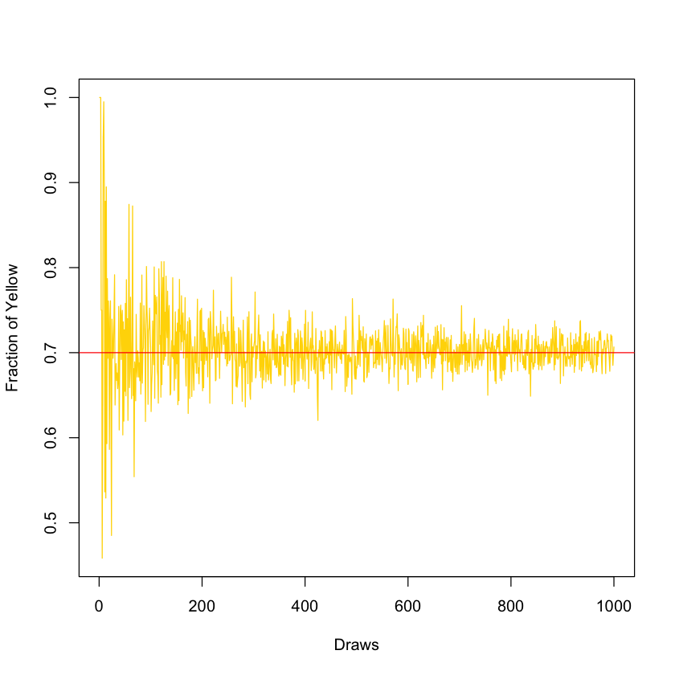

```r
#YOUR CODE HERE
set.seed(001);
#red = r, yellow = y, green = g, blue = b
urn <- c(rep('r',2), rep('y',70), rep('g',13), rep('b',15))
n = 1000
s = sample(urn, size = 1, replace = TRUE);
vec_fract = matrix(NA, ncol = 1, nrow=n)
y = 0
for (i in 1:n){
    x = sample(urn,i, replace = TRUE)
    for(j in 1:length(x)){
        y = y + ifelse(x[j] == 'y', 1, 0)
    }
    y = y/length(x)
    vec_fract[i] = y;
}
plot(vec_fract, type ="l", ylab = "Fraction of Yellow", xlab = "Draws", col = "gold" )
abline(0.7, 0, col='red')
```

The number fluctuates more when the numbers of draw is smaller because the smaller the draw the less data there is to calculate the fraction of draws properly. When there are more draws the we can approximate better since there are more outcomes to calculate.

**B.1(b) [3 points] About how many draws are needed before the proportion of yellow marbles drawn in the simulated data is within $0.1$ of the true probability of drawing a yellow marble? You can answer using a visual assessment of your plot from the previous part.**

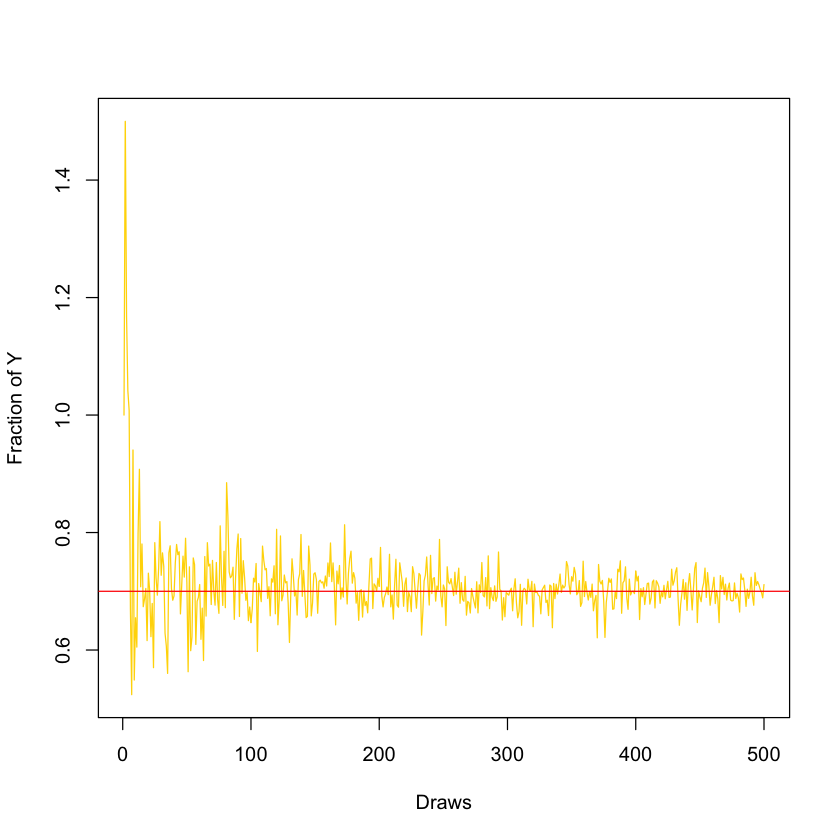

```r
#YOUR CODE HERE

#red = r, yellow = y, green = g, blue = b
urn <- c(rep('r',2), rep('y',70), rep('g',13), rep('b',15))
n = 500
s = sample(urn, size = 1, replace = TRUE);
vec_fract = matrix(NA, ncol = 1, nrow=n)
y = 0
for (i in 1:n){
    x = sample(urn,i, replace = TRUE)
    for(j in 1:length(x)){
        y = y + ifelse(x[j] == 'y', 1, 0)
    }
    y = y/length(x)
    vec_fract[i] = y;
}
plot(vec_fract, type ="l", ylab = "Fraction of Y", xlab = "Draws", col = "gold" )
abline(0.7, 0, col='red')
```

Looking at the graph, around 200 to 300, we begin to see the proportion of yellow be bounded by a tenth of 0.7